# Brauchle_HW5

Natascha Brauchle

March 2, 2019

**(1)** *(a)* Best subset will have the best training RSS because it has the most greedy approach.  
*(b)* Backward step selection may have the smallest test RSS because it is the least flexible and thus less likely to overfit the training set. However, it is difficult to determine exactly which one is best, as best subset may actually perform best if it does not overfit.

*(c)*  
*(i)* True  
*(ii)* True  
*(iii)* False  
*(iv)* False  
*(v)* False

**(2)**  
*(b)* (iii) Is true because it is less flexible.

**(4)**  
*(a)* (iii) Steadily increase. As $\lambda$ increases, $\beta$s will become more restricted and will deviate from their least squares estimates, and cause the model to become less flexible.  
*(b)* (ii) Decrease initially, and then eventually start increasing in a U shape. AS we increase $\lambda$ from 0, the $\beta$s will initially deviate more. However, as is typical for test RSS, it will decrease until increasing again.  
*(c)* (iv) Steadily Decrease. AS $\lambda$ increases, the model becomes less flexible.  
*(d)* (iii) Steadily increase. Again, the model becomes less flexible, which means that bias increases.  
*(e)*(v) Remain constant, because irreducible error is unaffected by parameters in the model.

**(9)**  
*(a)*

```r
college <- read.csv("Datasets/College.csv", header = TRUE)
college <- college[,-1]
set.seed(1)
subset <- sample(nrow(college), nrow(college)*.7)
train = college[subset,]
test <- college[-subset,]
```

*(b)* The test error for linear regression is 996667.4.

```r
lm.1 <- lm(Apps ~ ., data = train)
summary(lm.1)
```

```
##
## Call:
## lm(formula = Apps ~ ., data = train)
##
## Residuals:
##     Min      1Q  Median      3Q     Max
## -5103.0  -418.8   -15.8   294.7  7283.1
##
## Coefficients:
##               Estimate Std. Error t value Pr(>|t|)
## (Intercept) -3.295e+02  5.093e+02  -0.647 0.517888
## PrivateYes  -5.384e+02  1.686e+02  -3.194 0.001489 **
## Accept       1.626e+00  4.504e-02  36.095  < 2e-16 ***
## Enroll      -8.608e-01  2.117e-01  -4.065 5.53e-05 ***
## Top10perc    4.980e+01  6.924e+00   7.192 2.22e-12 ***
## Top25perc   -1.410e+01  5.490e+00  -2.568 0.010502 *
## F.Undergrad  4.006e-02  3.903e-02   1.027 0.305121
## P.Undergrad -2.472e-02  5.164e-02  -0.479 0.632401
## Outstate    -8.298e-02  2.323e-02  -3.573 0.000386 ***
## Room.Board   1.801e-01  5.915e-02   3.046 0.002438 **
## Books        9.931e-03  3.209e-01   0.031 0.975326
## Personal     6.038e-02  7.908e-02   0.764 0.445447
## PhD         -5.625e+00  6.051e+00  -0.930 0.352987
## Terminal    -6.677e+00  6.778e+00  -0.985 0.325082
## S.F.Ratio    1.372e+01  1.649e+01   0.832 0.405826
## perc.alumni -1.362e+00  5.094e+00  -0.267 0.789233
## Expend       7.129e-02  1.518e-02   4.696 3.40e-06 ***
## Grad.Rate    7.387e+00  3.751e+00   1.969 0.049438 *
## ---
## Signif. codes:  0 '***' 0.001 '**' 0.01 '*' 0.05 '.' 0.1 ' ' 1
##
## Residual standard error: 1068 on 525 degrees of freedom
## Multiple R-squared:  0.9357, Adjusted R-squared:  0.9336
## F-statistic: 449.1 on 17 and 525 DF,  p-value: < 2.2e-16
```

```r
p.apps <- predict(lm.1, test)
test.lm.error <- mean((test$Apps - p.apps)^2)
test.lm.error
```

```
## [1] 996667.4
```

*(c)* The test error for ridge regression is 999866.3, with a cross-validated lambda chosen as 431.7652. The graph shows that this lambda gives the smallest MSE.

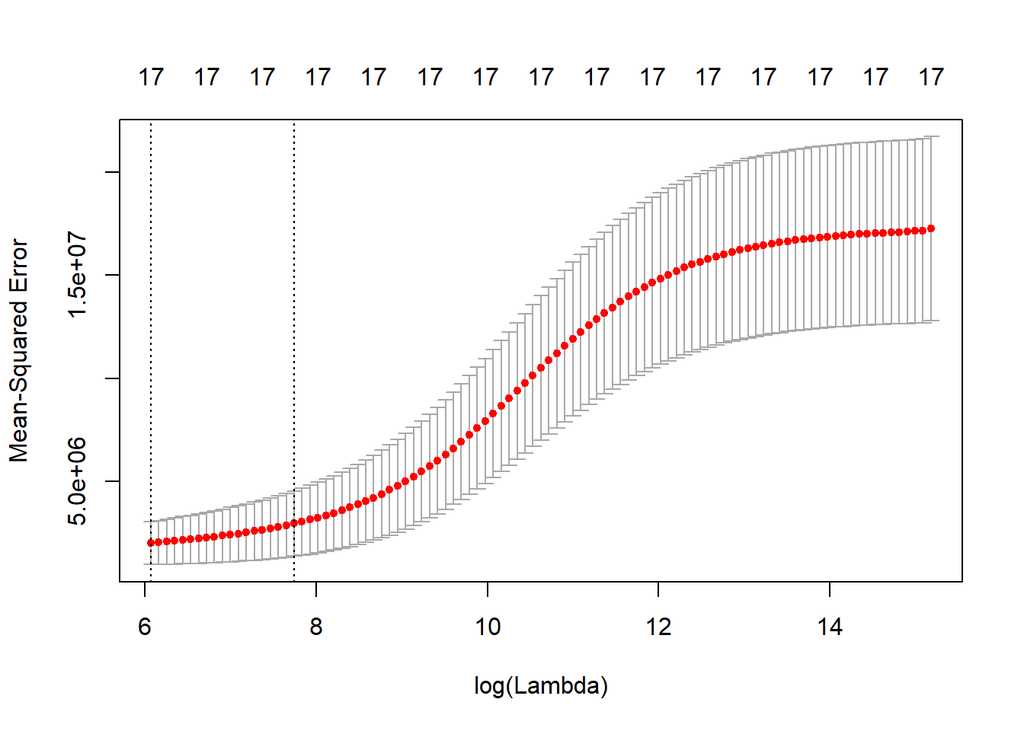

```r
train_matrix = model.matrix(Apps~., data = train)
test_matrix = model.matrix(Apps~ ., data = test)
cv.out <- cv.glmnet(train_matrix, train$Apps, alpha=0)
plot(cv.out)
```

```r
bestlam = cv.out$lambda.min
bestlam
```

```
## [1] 431.7652
```

```r
ridge.mod <- glmnet(train_matrix, train$Apps, alpha = 0, lambda = bestlam)

ridge.pred <- predict(ridge.mod, s = bestlam, newx = test_matrix)
test.ridge.error <- mean((ridge.pred - test$Apps)^2)
test.ridge.error
```

```
## [1] 999866.3
```

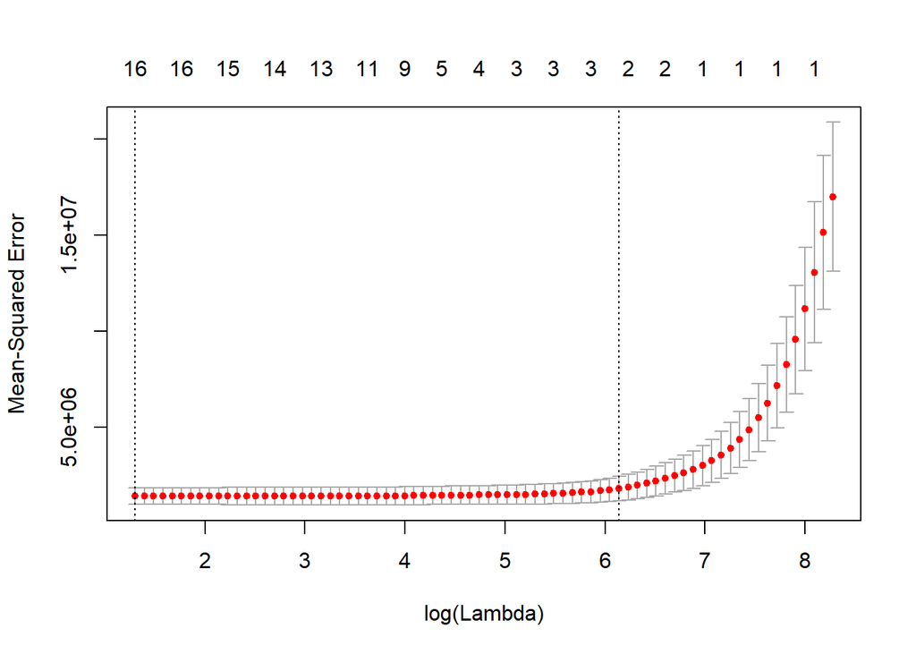

```r
cv.out <- cv.glmnet(train_matrix, train$Apps, alpha=1)
plot(cv.out)
```

```r
bestlam =cv.out$lambda.min
bestlam
```

```
## [1] 3.668939
```

```r
lasso.mod <- glmnet(train_matrix, train$Apps, alpha = 1, lambda = bestlam)
lasso.pred <- predict(lasso.mod, s = bestlam, newx = test_matrix)
test.lasso.error <- mean((lasso.pred - test$Apps)^2)
test.lasso.error
```

```
## [1] 992414.9
```

*(e)* The test error for principal components regression is 996667.4, with a cross-validated M chosen as 17. The graph shows that this M gives the smallest MSE.

```r
#pcr
pcr.fit <- pcr(Apps~., data = train, scale = TRUE, validation = "CV")
summary(pcr.fit)
```

```
## Data:    X dimension: 543 17
##  Y dimension: 543 1
## Fit method: svdpc
## Number of components considered: 17
##
## VALIDATION: RMSEP
## Cross-validated using 10 random segments.
##        (Intercept)  1 comps  2 comps  3 comps  4 comps  5 comps  6 comps
## CV            4149     4147     2212     2208     2200     1703     1714
## adjCV         4149     4150     2210     2207     2214     1696     1709
##        7 comps  8 comps  9 comps  10 comps  11 comps  12 comps  13 comps
## CV        1718     1723     1636      1638      1639      1640      1650
## adjCV     1714     1720     1631      1633      1635      1636      1646
##        14 comps  15 comps  16 comps  17 comps
## CV         1648      1622      1268      1240
## adjCV      1645      1596      1256      1229
##
## TRAINING: % variance explained
##       1 comps  2 comps  3 comps  4 comps  5 comps  6 comps  7 comps
## X     31.0810    57.75    64.64    70.47    75.97    80.89    84.37
## Apps   0.9531    72.02    72.58    72.90    83.93    84.05    84.13
##       8 comps  9 comps  10 comps  11 comps  12 comps  13 comps  14 comps
## X       87.75    90.53     92.92     94.99     96.79     97.91     98.72
## Apps    84.13    85.74     85.80     85.85     85.86     85.87     85.99
##       15 comps  16 comps  17 comps
## X        99.36     99.84    100.00
## Apps     91.02     93.29     93.57
```

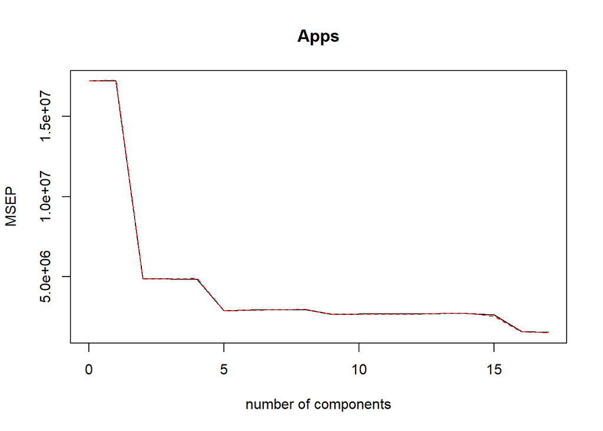

```r
validationplot(pcr.fit, val.type = "MSEP")
```

```r
pcr.pred = predict(pcr.fit, test, ncomp = 17)
test.pcr.error <- mean((pcr.pred - test$Apps)^2)
test.pcr.error
```

```
## [1] 996667.4
```

*(f)* The test error for partial least-squares regression is 997380.4, with a cross-validated M chosen as 11. The graph shows that this M gives the smallest MSE.

```r
set.seed(1)
pls.fit <- plsr(Apps ~ ., data=train, scale=TRUE, validation="CV")

summary(pls.fit)
```

```
## Data:    X dimension: 543 17
##  Y dimension: 543 1
## Fit method: kernelpls
## Number of components considered: 17
##
## VALIDATION: RMSEP
## Cross-validated using 10 random segments.
##        (Intercept)  1 comps  2 comps  3 comps  4 comps  5 comps  6 comps
## CV            4149     2023     1624     1574     1483     1352     1242
## adjCV         4149     2020     1614     1577     1466     1336     1231
##        7 comps  8 comps  9 comps  10 comps  11 comps  12 comps  13 comps
## CV        1239     1233     1230      1228      1225      1226      1225
## adjCV     1228     1223     1219      1217      1215      1216      1215
##        14 comps  15 comps  16 comps  17 comps
## CV         1225      1225      1225      1225
## adjCV      1215      1215      1215      1215
##
## TRAINING: % variance explained
##       1 comps  2 comps  3 comps  4 comps  5 comps  6 comps  7 comps
## X       26.58    34.50    62.81    65.71    70.16    73.53    77.38
## Apps    77.24    86.74    87.74    91.19    92.69    93.39    93.43
##       8 comps  9 comps  10 comps  11 comps  12 comps  13 comps  14 comps
## X       80.12    83.16     86.62     89.35     90.74     92.26     93.88
## Apps    93.49    93.52     93.54     93.55     93.56     93.57     93.57
##       15 comps  16 comps  17 comps
## X        96.08     98.25    100.00
## Apps     93.57     93.57     93.57
```

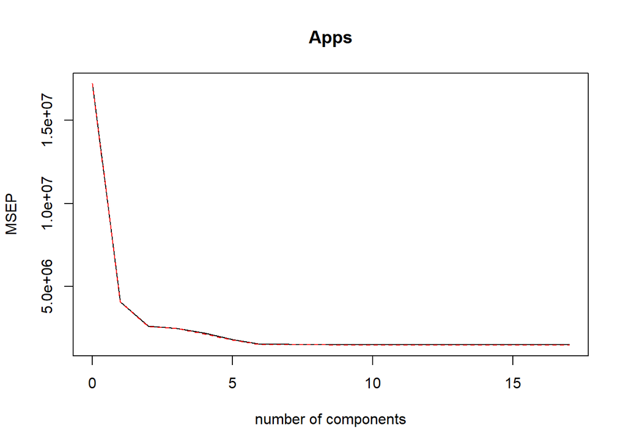

```r
validationplot(pls.fit ,val.type="MSEP")
```

```r
pls.pred = predict (pls.fit, test, ncomp = 11)
test.pls.error <- mean((pls.pred -test$Apps)^2)
test.pls.error
```

```
## [1] 997380.4
```

```r
# Calculate R^2 values

avg <- mean(test$Apps)
lm.rmse <- sqrt(test.lm.error)
ridge.rmse <- sqrt(test.ridge.error)
lasso.rmse <- sqrt(test.lasso.error)
pcr.rmse <- sqrt(test.pcr.error)
pls.rmse <- sqrt(test.pls.error)

rmse <- c(lm.rmse, ridge.rmse, lasso.rmse, pcr.rmse, pls.rmse)
rmse
```

```
## [1] 998.3323 999.9332 996.2002 998.3323 998.6893
```

**(10)** *(a)*

```r
set.seed(1)
p = 20
n = 1000

error <- sample(-1:10, n, replace = TRUE)
x <- matrix(rnorm(n*p),n, p)
b <- sample(-5:5, p, replace = TRUE)
b_0 <- sample(1:p, 4, replace = FALSE)
for (i in b_0){
  b[i] <- 0
}

y <- x %*% b + error
```

*(b)*

```r
subset <- sample(1:1000, 100, replace = FALSE)

q_10 <- data.frame(y, x)
train <- q_10[subset,]
test <- q_10[-subset,]
```

*(c)* As expected, the training MSE continually decreases as variables are added to the model. However, this likely causes overfitting.

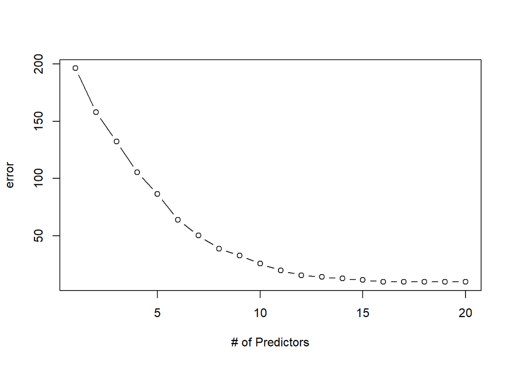

```r
predict.regsubsets <- function(object, newdata, id, ...){
  form <- as.formula(object$call[[2]])
  mat <- model.matrix(form, newdata)
  coefi <- coef(object, id=id)
  xvars <- names(coefi)
  mat[,xvars]%*%coefi
}
best.fit <- regsubsets(y~., data = train, nvmax = 20)
error <- rep(NA, 20)
for (i in 1:20) {
  pred <- predict(best.fit, train, id = i)
  error[i] <- mean((train$y - pred)^2)
}

plot(1:20, error, type = "b", xlab = "# of Predictors")
```

*(d)* Performance improves pretty drastically until we have about 12-13 predictors in the model. At that point, there are marginal improvements in the MSE.

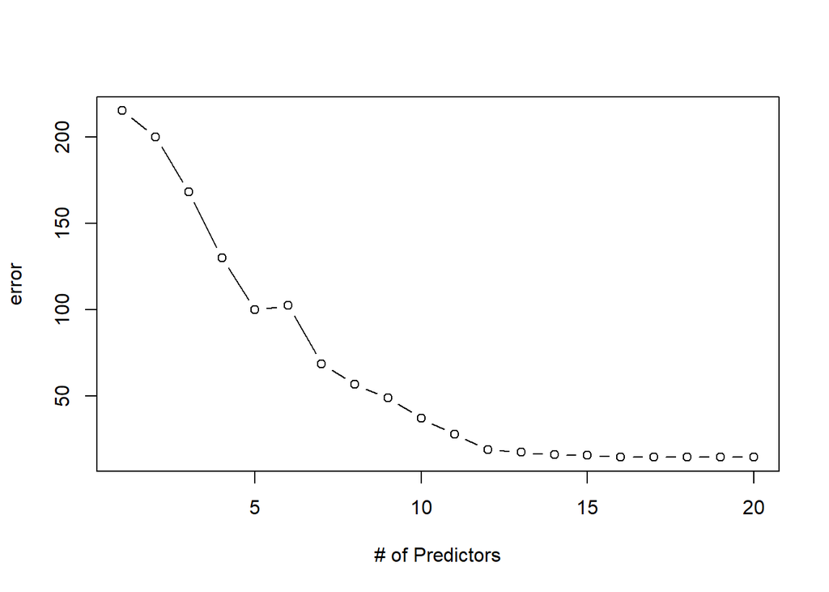

```r
error <- rep(NA, 20)
for (i in 1:20) {
  pred <- predict(best.fit, test, id = i)
  error[i] <- mean((test$y - pred)^2)
}

plot(1:20, error, type = "b", xlab = "# of Predictors")
```

*(e)* The smallest MSE in the test dataset is with 16 predictors. However, as discussed above, this minimum is marginally better than an MSE with only 12 predictors.

```r
which.min(error)
```

```
## [1] 16
```